# Suicide Rates Overview 1985 to 2015

DSC 520, Summer 2019, Final Project

Gourav Verma[^1]

Aug 8 2019

Abstract

According to the WHO Suicides organization, 800,000 committed suicide in 2018. This means every 40 seconds a person dies by suicide. This number is fortunately dropping. In this project I am trying to explore the evolution of suicide rate using dataset extracted from Kaggle. This compiled dataset pulled from four other datasets linked by time and place, and was built to find signals correlated to increased suicide rates among different cohorts globally, across the socio-economic spectrum.Majority of the data used in this analysis is obtained from World Health Organization.

#### **Structure of cleaned dataset**

Data cleaning notes

- 7 countries removed(<= 3 years of data total)
- 2016 data was removed(few countries data was present and those did had data missing)
- HDI variable was removed due to more than 50% data was missing.
- Generation and Age variable looks similar. We will find our in analysis later, if Generation variable produces different outcome.
- Created new variable ‘continent’ using countrycode package.
- Tdying data includes changing format of variables and arranging the values to ordinal.

```r
head(suicide)
```

|  | country | year | sex | age | suicides_no | population | gdp_for_year | gdp_per_capita | generation | continent |
| --- | --- | --- | --- | --- | --- | --- | --- | --- | --- | --- |
| 1 | Albania | 1987 | male | 15-24 | 21 | 312900 | 2,156,624,900 | 796 | Generation X | Europe |
| 2 | Albania | 1987 | male | 35-54 | 16 | 308000 | 2,156,624,900 | 796 | Silent | Europe |
| 3 | Albania | 1987 | female | 15-24 | 14 | 289700 | 2,156,624,900 | 796 | Generation X | Europe |
| 4 | Albania | 1987 | male | 75+ | 1 | 21800 | 2,156,624,900 | 796 | G.I. Generation | Europe |
| 5 | Albania | 1987 | male | 25-34 | 9 | 274300 | 2,156,624,900 | 796 | Boomers | Europe |
| 6 | Albania | 1987 | female | 75+ | 1 | 35600 | 2,156,624,900 | 796 | G.I. Generation | Europe |

### **Geographical heat map**

Below geographical heat map shows suicide rate for timeframe(1985-2015). **Grey area** shows lack of information for those countries, specially in **Africa and Asia**. TO get complete understanding of global trend we have limited data, but, we will continue with the data available.

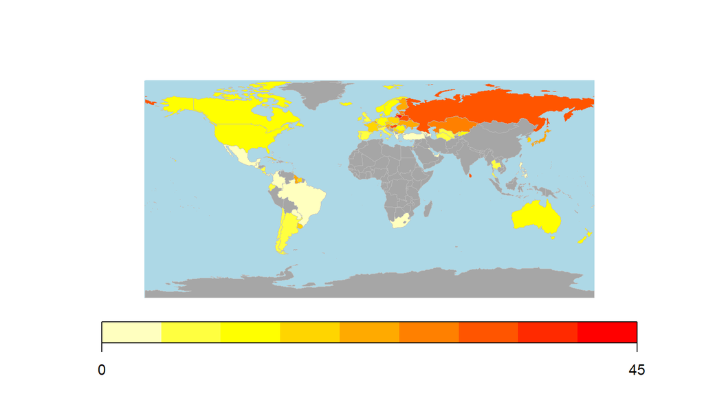

### **Global Analysis**

- Peak Suicide rate was **15.3** deaths per 100k in **1995**.
- Rates are now steadly decreasing and was **11.5** in **2015**.

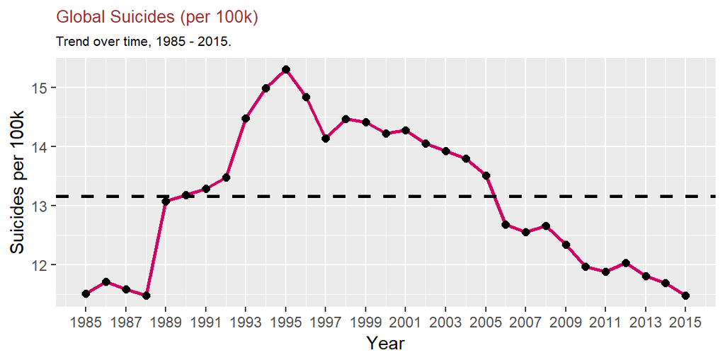

### **Continent Trend**

Below graph shows suicide rate variance over the time for different continents.

- **Europe has highest rate overall**, but steady decrease observed after 1995.
- Europe rate is similar to Asia and Oceania in 2015.
- **Oceania and American** trend is increasing over the time, which is concerning.

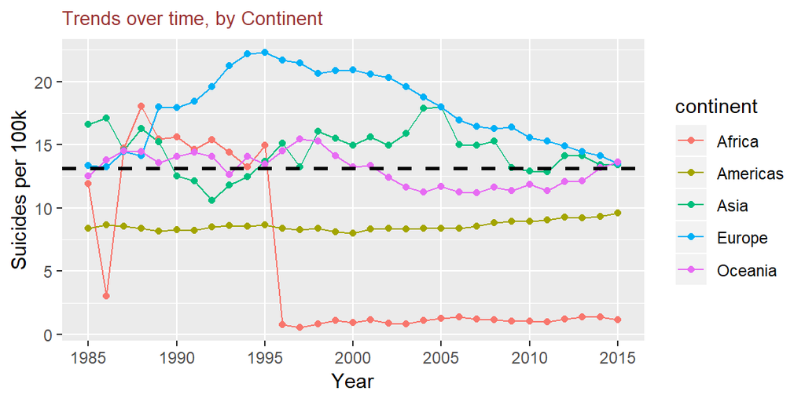

### **Trend by Sex**

- Globally, the rate of suicide for men has been **~3.5x higher for men**.
- Difference between male and female suicide rate might be affected by sex ratio.

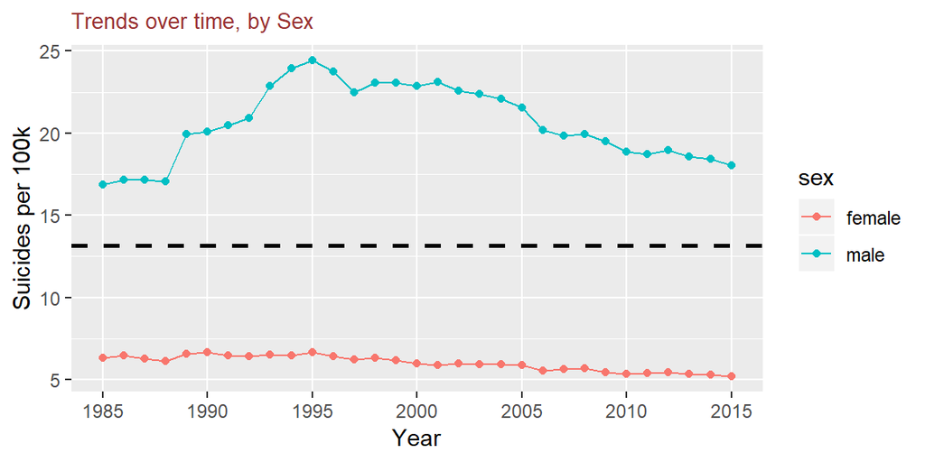

### **Trend by Age**

- Suicide rate **increases with age**.
- Rate of suicide is **highest** for age group **75+**.
- Rate for age group 5-14 appears static.

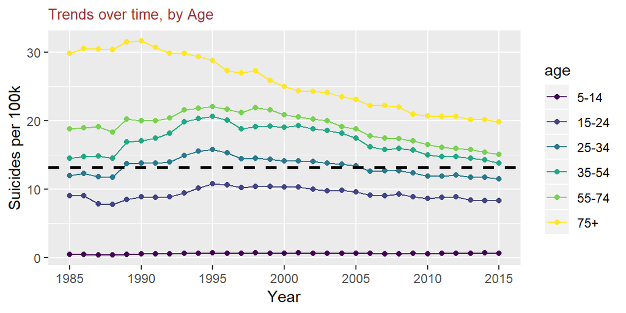

### **United States Trend Analysis**

Below plot shows data from 2010 to 2015 of United States. Bar chart is plotted to differentiate between male and female suicide rates.

- US suicide rates for men continues to **increase with age**.
- **Females** in US of age group **35-54** has higher suicide rate of **9 per 100k**.

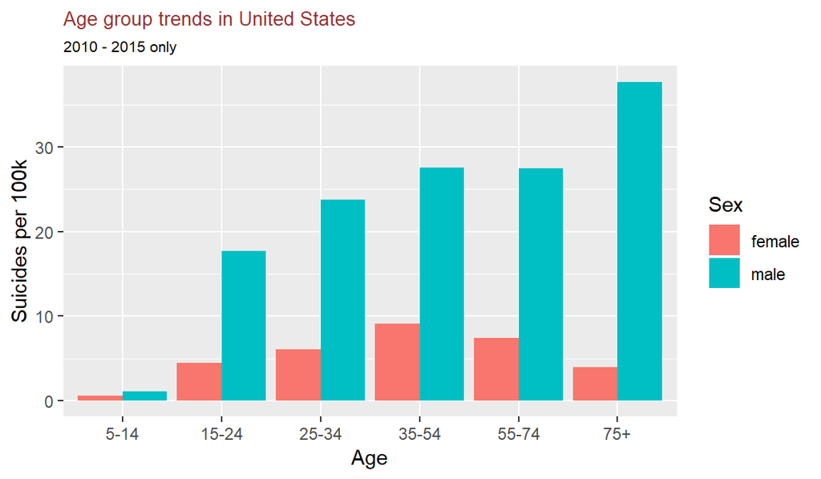

### **How Suicide Rate is related to GDP of a Country?**

Below is the correlation plot between GDP mean, Suicide rate per 100k and year, grouped by each country each year.

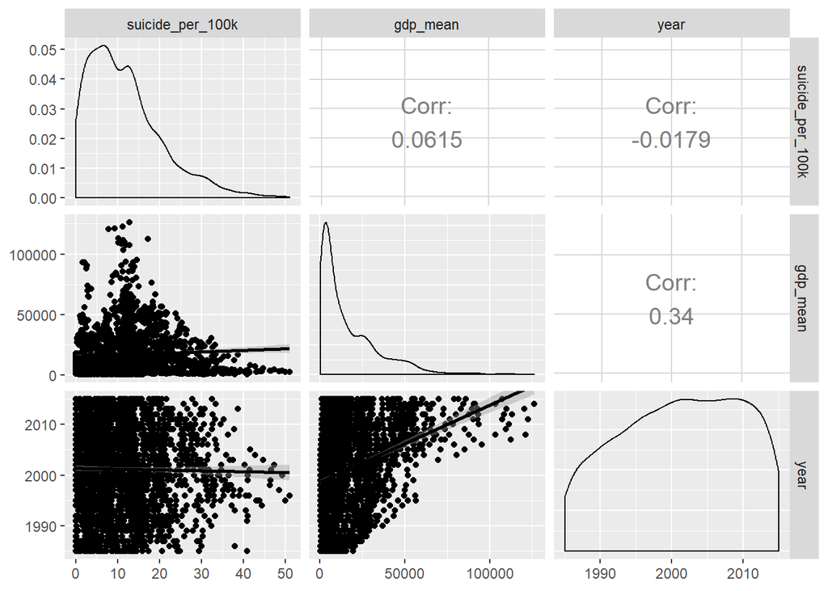

##### **References-**

- GitHub. (2019). vincentarelbundock/countrycode. [online] Available at: https://github.com/vincentarelbundock/countrycode [Accessed 8 Aug. 2019].
- Rusty. “Suicide Rates Overview 1985 to 2016.” Kaggle, 1 Dec. 2018, www.kaggle.com/russellyates88/suicide-rates-overview-1985-to-2016
- United Nations Development Program. (2018). Human development index (HDI). Retrieved from http://hdr.undp.org/en/indicators/137506
- World Bank. (2018). World development indicators: GDP (current US$) by country:1985 to 2016. Retrieved from http://databank.worldbank.org/data/source/world-development-indicators#
- [Szamil]. (2017). Suicide in the Twenty-First Century [dataset]. Retrieved from https://www.kaggle.com/szamil/suicide-in-the-twenty-first-century/notebook
- World Health Organization. (2018). Suicide prevention. Retrieved from http://www.who.int/mental_health/suicide-prevention/en/
[^1]: Bellevue University, Nebraska